# Lab5: Testowanie wielu hipotez

Michał Ciach, Anna Macioszek

March 15, 2020

Jezeli plik otwiera sie bez polskich liter, otworzcie go jeszcze raz uzywajac “Reopen with encoding” i wybierzcie UTF-8.

**Zadanie 2.** *(podchwytliwe).* W danych `Zarobki.csv` znajdują się miesięczne zarobki losowo wybranych obywateli krajów A i B. Wykorzystując poznane dotychczas techniki analizy danych, spróbuj odpowiedzieć na pytanie: *Obywatele którego kraju są bogatsi?*.

```r
data<-read.csv("Zarobki.csv",sep="\t")
zarobki_a=data[data$Kraj=="A",2]
zarobki_b=data[data$Kraj=="B",2]
t.test(x=zarobki_a,y=zarobki_b,alternative="two.sided")
```

```
##
##  Welch Two Sample t-test
##
## data:  zarobki_a and zarobki_b
## t = -2.0811, df = 1017.8, p-value = 0.03767
## alternative hypothesis: true difference in means is not equal to 0
## 95 percent confidence interval:
##  -1029.62911   -30.26084
## sample estimates:
## mean of x mean of y
##  4802.606  5332.551
```

### Testowanie wielokrotne

**Zadanie 3.** Zainstaluj i załaduj bibliotekę `ISLR`. Załaduj dane `Khan` za pomocą komendy `data(Khan)` (zwróć uwagę na brak cudzysłowu).  
Dane dotyczą ekspresji genów w zależności od rodzaju nowotworu. Wyniki pomiaru ekspresji genów zapisane są w polu `Khan$xtrain`, a rodzaj nowotworu w polu `Khan$ytrain`. Więcej informacji na temat danych możesz znaleźć w dokumentacji, którą możesz wyświetlić w Rstudio wpisując w konsolę `?Khan` lub `help(Khan)`.

- Wybierz te wiersze z macierzy `Khan$xtrain`, które odpowiadają rodzajowi 2 oraz 4, i zapisz je w dwóch macierzach.
- Dla każdego genu sprawdź, czy jego ekspresja zależy od rodzaju nowotworu, używając funkcji `t.test` do przeprowadzenia testu Welsha (czyli testu t Studenta dla prób o różnych wariancjach). Zapisz otrzymane p-wartości w wektorze.
- Przeprowadź korekcje p-wartości metodami Bonferroniego, Holma, oraz Benjamini-Hochberg.

```r
library(ISLR)
data(Khan)
dwa<-Khan$xtrain[which((Khan$ytrain==2)!=0),]
cztery<-Khan$xtrain[which((Khan$ytrain==4)!=0),]
wyniki<-sapply(1:20,(function (x)t.test(dwa[x,],cztery[x,])$p.value ))
print(p.adjust(wyniki,method = "bonferroni"))
```

```
##  [1] 1.799230e-11 2.171164e-27 1.000000e+00 8.208817e-02 1.000000e+00
##  [6] 1.000000e+00 9.991834e-13 3.238609e-07 1.000000e+00 3.330144e-10
## [11] 1.000000e+00 1.000000e+00 1.000000e+00 6.625000e-05 1.000000e+00
## [16] 1.186846e-10 3.063209e-35 9.836580e-01 1.000000e+00 3.525765e-16
```

```r
print(p.adjust(wyniki,method = "hochberg"))
```

```
##  [1] 1.439384e-11 2.062606e-27 7.979238e-01 4.514849e-02 7.979238e-01
##  [6] 7.979238e-01 8.493059e-13 2.105096e-07 7.979238e-01 2.331101e-10
## [11] 7.979238e-01 7.979238e-01 7.979238e-01 3.975000e-05 7.979238e-01
## [16] 8.901344e-11 3.063209e-35 4.918290e-01 7.979238e-01 3.173188e-16
```

```r
print(p.adjust(wyniki,method = "holm"))
```

```
##  [1] 1.439384e-11 2.062606e-27 1.000000e+00 4.514849e-02 9.491301e-01
##  [6] 1.000000e+00 8.493059e-13 2.105096e-07 1.000000e+00 2.331101e-10
## [11] 8.478103e-01 9.491301e-01 1.000000e+00 3.975000e-05 1.000000e+00
## [16] 8.901344e-11 3.063209e-35 4.918290e-01 1.000000e+00 3.173188e-16
```

1. Chcemy znaleźć geny, które są potencjalnym celem terapii genowej, i mamy środki na kilkadziesiąt dalszych eksperymentów
2. Chcemy znaleźć geny, które mogą być potencjalnym celem niesamowicie drogiego eksperymentu mającego na celu przetestowanie nowej metody leczenia
3. Chcemy wstępnie określić, które geny mogą mieć związek z danym typem nowotworu
4. Chcemy ogólnie scharakteryzować, które geny mają różną ekspresję w różnych typach nowotworu
5. Chcemy znaleźć geny markerowe, czyli takie, które pozwolą na efektywne rozróznienie typu nowotworu

**Zadanie 5.** Stwórz macierz o wymiarach 10x1000, taką, że obserwacje z pierwszych stu kolumn są wylosowane z rozkładu $\mathcal{N}(1, 1)$, a z pozostałych 900 z rozkładu $\mathcal{N}(0, 1)$. Następnie:

- Dla każdej kolumn przeprowadź test t Studenta na to, czy średnia jest większa od 0, i zapisz otrzymane p-wartości w wektorze.
- Przeprowadź korekcje p-wartości za pomocą metod Bonferroniego, Holma, oraz Bejnamini-Hochberga, korzystając z funkcji `p.adjust`.
- Obejrzyj rozkłady p-wartości oraz q-wartości (skorygowanych p-wartości) na histogramach.
- Zapisz oryginalne p-wartości i trzy wektory q-wartości w ramce danych lub macierzy o 4 kolumnach.
- Dla każdej kolumny oblicz moc testu, False Discovery Rate, False Positive Rate, accuracy oraz precision przyjmując poziom istotności 0.05. Zinterpretuj wyniki.

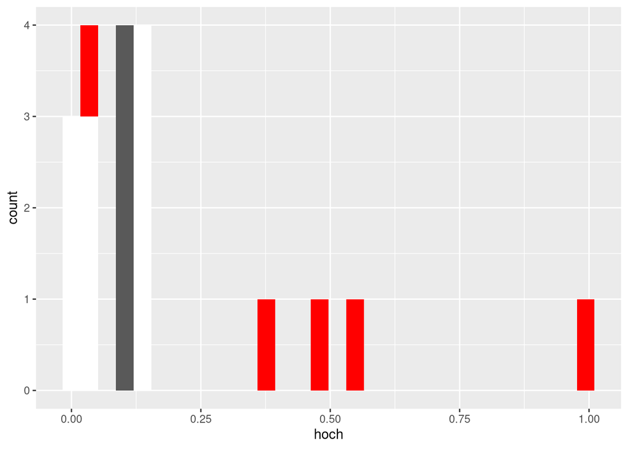

```r
mat<-matrix(c(rnorm(1000,0,1),rnorm(9000,1,1)),nrow=10)
pval<-apply(mat,MARGIN = 1,function (i) t.test(x=i,mu=1)$p.value)
d<-data.frame(
bon=p.adjust(pval,method = "bonferroni"),
hoch=p.adjust(pval,method = "hochberg"),
holm=p.adjust(pval,method = "holm")
)
ggplot(d)+geom_histogram(aes(x=hoch))+geom_histogram(aes(x=bon),fill="red")+geom_histogram(aes(x=holm),fill="white")
```